# Project Python Foundations: FoodHub Data Analysis

### Context

The number of restaurants in New York is increasing day by day. Lots of students and busy professionals rely on those restaurants due to their hectic lifestyles. Online food delivery service is a great option for them. It provides them with good food from their favorite restaurants. A food aggregator company FoodHub offers access to multiple restaurants through a single smartphone app.

The app allows the restaurants to receive a direct online order from a customer. The app assigns a delivery person from the company to pick up the order after it is confirmed by the restaurant. The delivery person then uses the map to reach the restaurant and waits for the food package. Once the food package is handed over to the delivery person, he/she confirms the pick-up in the app and travels to the customer's location to deliver the food. The delivery person confirms the drop-off in the app after delivering the food package to the customer. The customer can rate the order in the app. The food aggregator earns money by collecting a fixed margin of the delivery order from the restaurants.

### Objective

The food aggregator company has stored the data of the different orders made by the registered customers in their online portal. They want to analyze the data to get a fair idea about the demand of different restaurants which will help them in enhancing their customer experience. Suppose you are hired as a Data Scientist in this company and the Data Science team has shared some of the key questions that need to be answered. Perform the data analysis to find answers to these questions that will help the company to improve the business.

### Data Description

The data contains the different data related to a food order. The detailed data dictionary is given below.

### Data Dictionary

- order_id: Unique ID of the order
- customer_id: ID of the customer who ordered the food
- restaurant_name: Name of the restaurant
- cuisine_type: Cuisine ordered by the customer
- cost_of_the_order: Cost of the order
- day_of_the_week: Indicates whether the order is placed on a weekday or weekend (The weekday is from Monday to Friday and the weekend is Saturday and Sunday)
- rating: Rating given by the customer out of 5
- food_preparation_time: Time (in minutes) taken by the restaurant to prepare the food. This is calculated by taking the difference between the timestamps of the restaurant's order confirmation and the delivery person's pick-up confirmation.
- delivery_time: Time (in minutes) taken by the delivery person to deliver the food package. This is calculated by taking the difference between the timestamps of the delivery person's pick-up confirmation and drop-off information

### Let us start by importing the required libraries

```python
# Installing the libraries with the specified version.
!pip install numpy==1.25.2 pandas==1.5.3 matplotlib==3.7.1 seaborn==0.13.1 -q --user
```

[output not shown]

Observations: The code is getting error because they are already installed. We will get this error after first time run this code.

**Note**:

- After running the above cell, kindly restart the runtime (for Google Colab) or notebook kernel (for Jupyter Notebook), and run all cells sequentially from the next cell.
- On executing the above line of code, you might see a warning regarding package dependencies. This error message can be ignored as the above code ensures that all necessary libraries and their dependencies are maintained to successfully execute the code in **this notebook**.

```python
# import libraries for data manipulation
import numpy as np
import pandas as pd

# import libraries for data visualization
import matplotlib.pyplot as plt
import seaborn as sns
```

### Understanding the structure of the data

```python
# uncomment and run the below code snippets if the dataset is present in the Google Drive
from google.colab import drive
drive.mount('/content/drive')
```

```python
# Write your code here to read the data
path="/content/drive/MyDrive/Colab Notebooks/foodhub_order.csv"
df= pd.read_csv(path)
```

```python
# Write your code here to view the first 5 rows
df.head()
```

|  | order_id | customer_id | restaurant_name | cuisine_type | cost_of_the_order | day_of_the_week | rating | food_preparation_time | delivery_time |
| --- | --- | --- | --- | --- | --- | --- | --- | --- | --- |
| 0 | 1477147 | 337525 | Hangawi | Korean | 30.75 | Weekend | Not given | 25 | 20 |
| 1 | 1477685 | 358141 | Blue Ribbon Sushi Izakaya | Japanese | 12.08 | Weekend | Not given | 25 | 23 |
| 2 | 1477070 | 66393 | Cafe Habana | Mexican | 12.23 | Weekday | 5 | 23 | 28 |
| 3 | 1477334 | 106968 | Blue Ribbon Fried Chicken | American | 29.20 | Weekend | 3 | 25 | 15 |
| 4 | 1478249 | 76942 | Dirty Bird to Go | American | 11.59 | Weekday | 4 | 25 | 24 |

### **Question 1:** How many rows and columns are present in the data? [0.5 mark]

```python
# Write your code here
row_count = df.shape[0]
col_count = df.shape[1]
row_count
col_count
print("Number of rows :", row_count)
print("Number of columns :", col_count)
```

```
Number of rows : 1898
Number of columns : 9
```

#### Observations:

Number of rows : 1898 Number of columns : 9

### **Question 2:** What are the datatypes of the different columns in the dataset? (The info() function can be used) [0.5 mark]

```python
# Write your code here
df.info()
```

```
<class 'pandas.core.frame.DataFrame'>
RangeIndex: 1898 entries, 0 to 1897
Data columns (total 9 columns):
 #   Column                 Non-Null Count  Dtype
---  ------                 --------------  -----
 0   order_id               1898 non-null   int64
 1   customer_id            1898 non-null   int64
 2   restaurant_name        1898 non-null   object
 3   cuisine_type           1898 non-null   object
 4   cost_of_the_order      1898 non-null   float64
 5   day_of_the_week        1898 non-null   object
 6   rating                 1898 non-null   object
 7   food_preparation_time  1898 non-null   int64
 8   delivery_time          1898 non-null   int64
dtypes: float64(1), int64(4), object(4)
memory usage: 133.6+ KB
```

#### Observations:

int64 , object and float64

### **Question 3:** Are there any missing values in the data? If yes, treat them using an appropriate method. [1 mark]

```python
missing_value= df.isnull().sum()
#missing_value= df.isna().sum()
missing_value
```

|  | 0 |
| --- | --- |
| order_id | 0 |
| customer_id | 0 |
| restaurant_name | 0 |
| cuisine_type | 0 |
| cost_of_the_order | 0 |
| day_of_the_week | 0 |
| rating | 0 |
| food_preparation_time | 0 |
| delivery_time | 0 |

**dtype:** int64

#### Observations:

There is no missing value

### **Question 4:** Check the statistical summary of the data. What is the minimum, average, and maximum time it takes for food to be prepared once an order is placed? [2 marks]

```python
# Write your code here
min_prep_time= df['food_preparation_time'].min()
max_prep_time= df['food_preparation_time'].max()
avg_prep_time= df['food_preparation_time'].mean()
print("Minimum food preparation time:", min_prep_time)
print("Maximum food preparation time:", max_prep_time)
print("Average food preparation time:", avg_prep_time)
```

```
Minimum food preparation time: 20
Maximum food preparation time: 35
Average food preparation time: 27.371970495258168
```

#### Observations:

- Minimum food preparation time: 20
- Maximum food preparation time: 35
- Average food preparation time: 27.371970495258168

### **Question 5:** How many orders are not rated? [1 mark]

```python
# Write the code here
no_rating= df[df['rating']=='Not given'].shape[0]
print("orders with no rating:", no_rating)
```

```
orders with no rating: 736
```

#### Observations:

orders with no rating: 736

### Exploratory Data Analysis (EDA)

### **Question 6:** Explore all the variables and provide observations on their distributions. (Generally, histograms, boxplots, countplots, etc. are used for univariate exploration.) [9 marks]

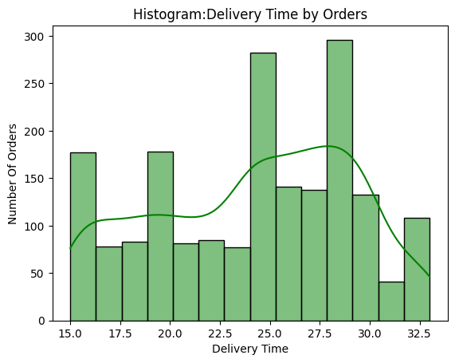

```python
# Histogram to show the delivery time across the orders
plt.title('Histogram:Delivery Time by Orders')
plt.xlabel('Delivery Time')
plt.ylabel('Number Of Orders')
sns.histplot(data=df, x='delivery_time', color='green', kde=True);
```

Observations: Delivery time for most of the orders range from 24mins to 30mins

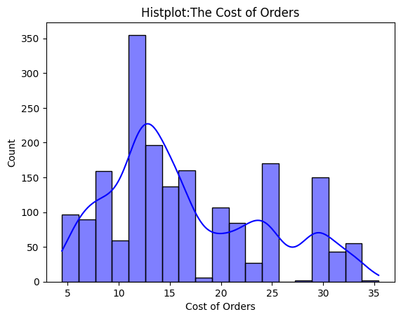

```python
# Histogram to show the cost of orders across all resturants
plt.title('Histplot:The Cost of Orders')
plt.xlabel('Cost of Orders')
sns.histplot(data=df, x='cost_of_the_order', color='blue', kde=True);
```

Observations:

1. Minimum cost of a single order is around 5 dollar and the maximum cost is around 35 dollar
2. Most of the orders were between 12 to 22 in dollars
3. 350 orders were cost around 11 to 13 dollar, highest number of orders in this range

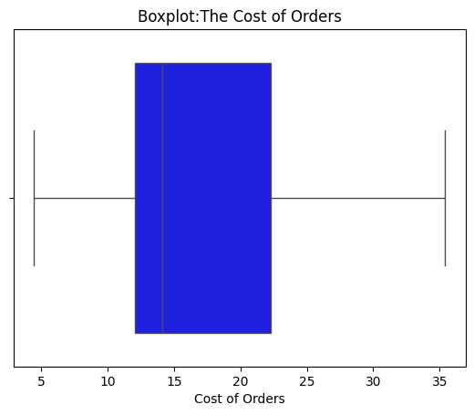

```python
# Boxplot to show the cost of orders across all resturants
plt.title('Boxplot:The Cost of Orders')
plt.xlabel('Cost of Orders')
sns.boxplot(data=df, x='cost_of_the_order', color='blue');
```

Observations:

1. Boxplot shows most of the orders were between 12 to 22 in dollars
2. Most expensive order cost around 35 dollar

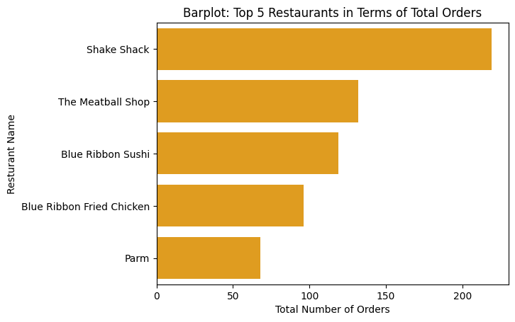

```python
# Countplot to show the top 5 restaurants in terms of total number of orders
plt.title('Barplot: Top 5 Restaurants in Terms of Total Orders')
plt.ylabel('Resturant Name')
plt.xlabel('Total Number of Orders')
sns.countplot(data=df, y='restaurant_name', order=df['restaurant_name'].value_counts().index[:5], color='orange');
```

Observations:

1. Highest number of orders are from "Shake Shack" restaurant, around 200 orders are from this restaurant

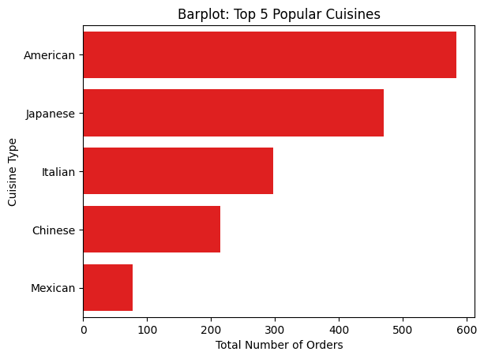

```python
# Countplot to show the top 5 popular cuisines
plt.title('Barplot: Top 5 Popular Cuisines')
plt.ylabel('Cuisine Type')
plt.xlabel('Total Number of Orders')
sns.countplot(data=df, y='cuisine_type', order=df['cuisine_type'].value_counts().index[:5], color='red');
```

Observations:

1. Top 5 cuisines ordered American, Japanese, Italian, Chinese and Mexican
2. Around 600 oredrs are American cuisine most highest order

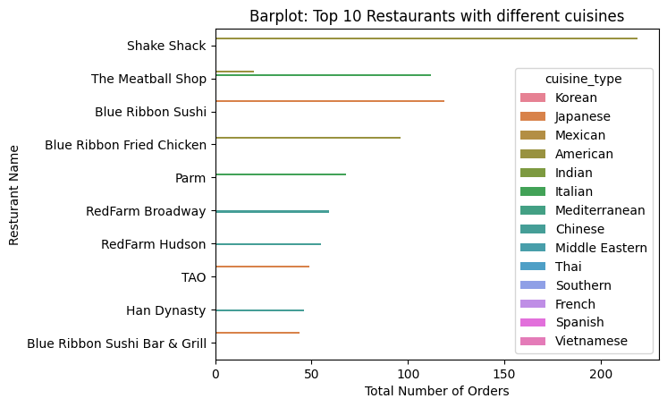

```python
# Countplot to show the top 10 restaurants with different cuisine type
plt.title('Barplot: Top 10 Restaurants with different cuisines')
plt.ylabel('Resturant Name')
plt.xlabel('Total Number of Orders')
sns.countplot(data=df, y='restaurant_name', order=df['restaurant_name'].value_counts().index[:10], hue='cuisine_type');
```

Observations:

1. From the top 10 restaurants in terms of total orders, only the 2nd highest order restaurant "The Meatball Shop" sold 2 types of cuisines: Italian and American. Rest all the restaurants sold only one type of cuisine

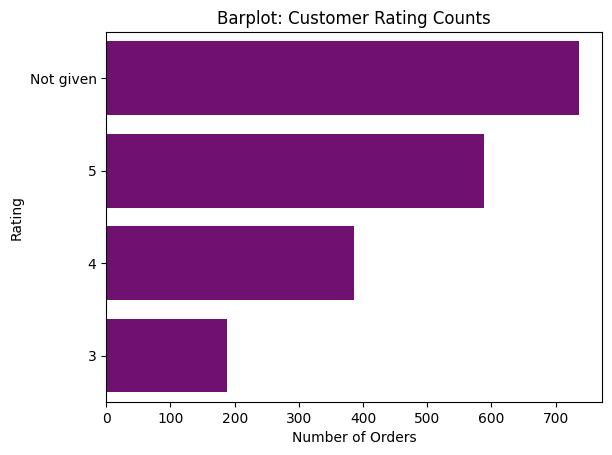

```python
#Countplot to show the ratings vs total number of orders
plt.title("Barplot: Customer Rating Counts")
plt.ylabel('Rating')
plt.xlabel('Number of Orders')
sns.countplot(data=df, y='rating', order=df['rating'].value_counts().index[:10],color='purple');
```

Observations:

1. 600 orders got 5 ratings, 400 orders got 4 ratings and around 190 orders got 3 ratings
2. There is no rating for around 700 orders

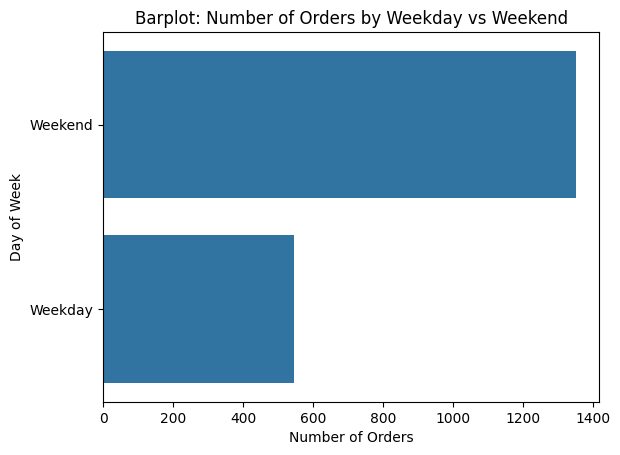

```python
#Countplot to show the Total number of orders Weekday vs Weekend
plt.title("Barplot: Number of Orders by Weekday vs Weekend")
plt.ylabel('Day of Week')
plt.xlabel('Number of Orders')
sns.countplot(data=df, y='day_of_the_week', order=df['day_of_the_week'].value_counts().index[:2]);
```

Observations:

1. Total weekend orders more than 1300
2. Total weekdays order is just 500+

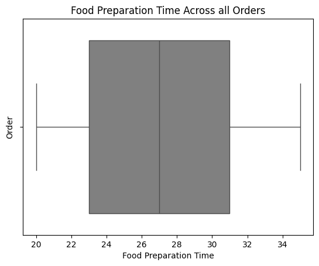

```python
#Boxplot is to analyze the food preperation time across all orders.
plt.title(f"Food Preparation Time Across all Orders")
plt.xlabel('Food Preparation Time')
plt.ylabel('Order')
sns.boxplot(data=df, x='food_preparation_time',color='grey')
```

Observations:

### **Question 7**: Which are the top 5 restaurants in terms of the number of orders received? [1 mark]

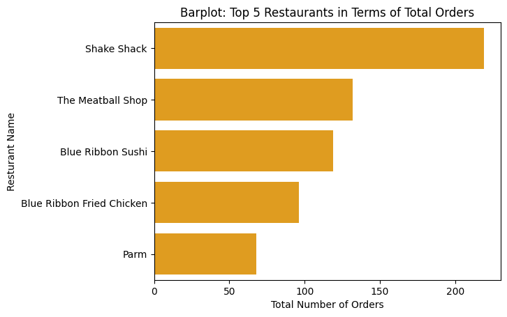

```python
# Countplot to show the top 5 restaurants in terms of total number of orders
plt.title('Barplot: Top 5 Restaurants in Terms of Total Orders')
plt.ylabel('Resturant Name')
plt.xlabel('Total Number of Orders')
sns.countplot(data=df, y='restaurant_name', order=df['restaurant_name'].value_counts().index[:5], color='orange');
```

Observations: The top 5 restaurants in term of order received:

1. Shake Shack
2. The Meatball Shop
3. Blue Ribbon Sushi
4. Blue Ribbon Fried Chicken
5. Parm Top os Shake Shack, it received around 200 orders

### **Question 8**: Which is the most popular cuisine on weekends? [1 mark]

```python
weekend_data = df[df['day_of_the_week']=='Weekend']
Popular_cuisine = weekend_data['cuisine_type'].value_counts().head(1)
Popular_cuisine
```

| cuisine_type | count |
| --- | --- |
| American | 415 |

**dtype:** int64

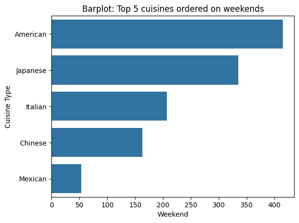

```python
# Countplot to show the top 5 cuisines ordered on weekends
plt.title('Barplot: Top 5 cuisines ordered on weekends')
plt.ylabel('Cuisine Type')
plt.xlabel('Weekend')
weekend_data = df[df['day_of_the_week']=='Weekend']
sns.countplot(data=weekend_data, y='cuisine_type', order=weekend_data['cuisine_type'].value_counts().index[:5]);
```

#### Observations:

The most popular cuisine is "American Cuisine" with 415 orders on weekends

### **Question 9**: What percentage of the orders cost more than 20 dollars? [2 marks]

```python
# Get the count of all the orders cost more than 20 dollar
order_cost_more20 = df[df['cost_of_the_order']>20].shape[0]

#Total order count
total_orders = df.shape[0]

#Get the percentage of the orders cost more than 20 dollar
percentage = (order_cost_more20/total_orders)*100
print('Percentage of orders cost more than 20 dollars: ', percentage)
```

```
Percentage of orders cost more than 20 dollars:  29.24130663856691
```

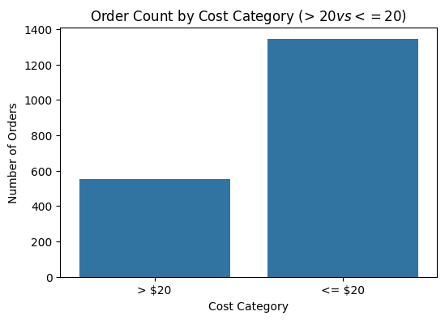

```python
# Categorize orders based on cost
df['cost_category'] = df['cost_of_the_order'].apply(lambda x: '> $20' if x > 20 else '<= $20')

# Countplot to show order count based on cost category
plt.figure(figsize=(6, 4))
sns.countplot(data=df, x='cost_category')
plt.title('Order Count by Cost Category (> $20 vs <= $20)')
plt.xlabel('Cost Category')
plt.ylabel('Number of Orders')
plt.show()
```

#### Observations:

1. 29.24% orders cost more than 20 dollar
2. More than 1300 orders cost less than 20 dollar and 500+ orders cost more than 20 dollar

### **Question 10**: What is the mean order delivery time? [1 mark]

```python
mean_delivery_time= df['delivery_time'].mean()
print("Mean Delivery Time: ", mean_delivery_time)
```

```
Mean Delivery Time:  24.161749209694417
```

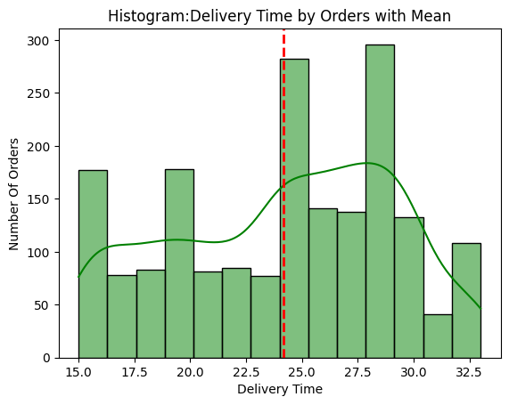

```python
# Histogram to show the delivery time across the orders
plt.title('Histogram:Delivery Time by Orders with Mean')
plt.xlabel('Delivery Time')
plt.ylabel('Number Of Orders')
sns.histplot(data=df, x='delivery_time', color='green', kde=True);

mean_delivery_time= df['delivery_time'].mean()
plt.axvline(mean_delivery_time, color='red', linestyle='dashed', linewidth=2, label='mean')
```

#### Observations:

Mean Delivery time is 24.16 minutes

### **Question 11:** The company has decided to give 20% discount vouchers to the top 3 most frequent customers. Find the IDs of these customers and the number of orders they placed. [1 mark]

```python
top3_customers= df['customer_id'].value_counts().head(3)
print("Top 3 most frequent customers: \n", top3_customers)
```

```
Top 3 most frequent customers:
 customer_id
52832    13
47440    10
83287     9
Name: count, dtype: int64
```

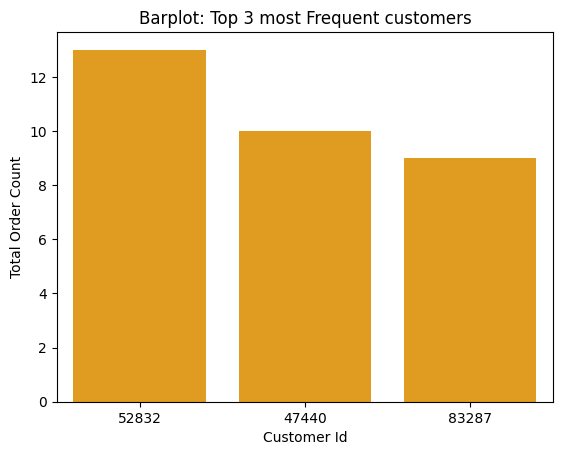

```python
# Countplot to show the top 3 most Frequent customers
plt.title('Barplot: Top 3 most Frequent customers')
plt.ylabel('Total Order Count')
plt.xlabel('Customer Id')
sns.countplot(data=df, x='customer_id', order=df['customer_id'].value_counts().index[:3], color='orange');
```

#### Observations:

Top frequent customer with customer_id= 52832, total order 13. Second customer with customer_id = 47440, total order 10 and 3rd top frequest customer with customer_id = 83287, total order 9

### **Question 12**: Perform a multivariate analysis to explore relationships between the important variables in the dataset. (It is a good idea to explore relations between numerical variables as well as relations between numerical and categorical variables) [10 marks]

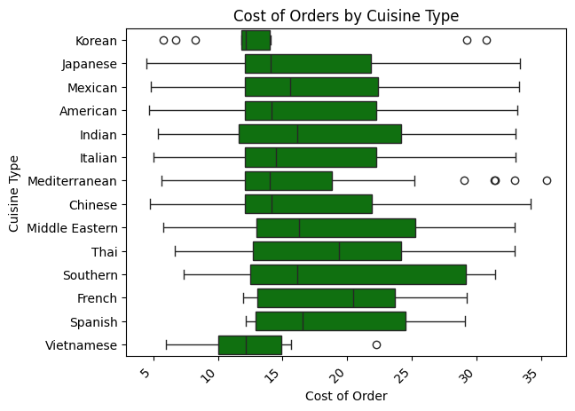

```python
# Create a boxplot to cuisine type to cost of order
sns.boxplot(data=df, x='cost_of_the_order', y='cuisine_type', color='green');
plt.xticks(rotation=45, ha='right');
plt.title('Cost of Orders by Cuisine Type');
plt.xlabel('Cost of Order');
plt.ylabel('Cuisine Type');
```

Observations: Vietnamese is the least expensive cuisine. Starting price of French and Spanish cuisines are high as compared to the other cuisines.

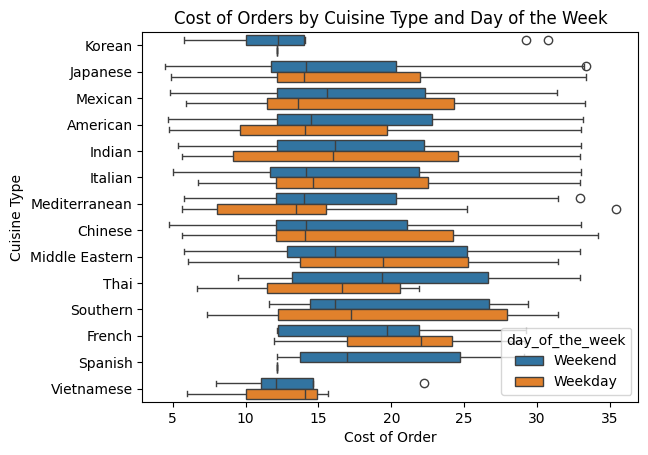

```python
# Plot the cost of orders by cuisine type and day of the week
sns.boxplot(data=df, x='cost_of_the_order', y='cuisine_type',
            hue='day_of_the_week');
plt.title('Cost of Orders by Cuisine Type and Day of the Week');
plt.xlabel('Cost of Order');
plt.ylabel('Cuisine Type');
```

Observations: Median price of "French" and "Middle Eastern" cuisines are high on weekdays. Median price of "Thai" food is higher on weekends

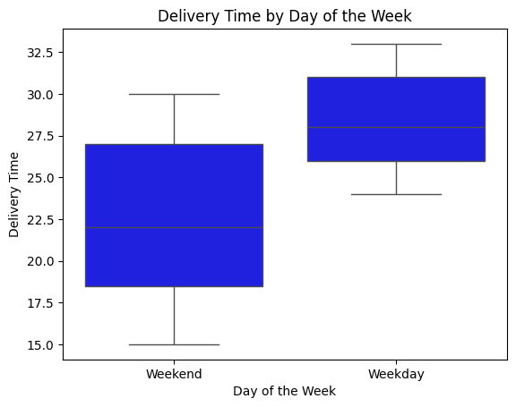

```python
# Plot the Delivery Time based on the Day of the Week
sns.boxplot(data=df, x='day_of_the_week',
            y='delivery_time',color='blue');
plt.title('Delivery Time by Day of the Week');
plt.xlabel('Day of the Week');
plt.ylabel('Delivery Time');
```

Observations: Delivery time is much higher on weekdays.Weekend delivery time starts from 15 minutes and average is around 22 minutes. On weekdays delivery time starts from 24 minutes and average time is 28 minutes

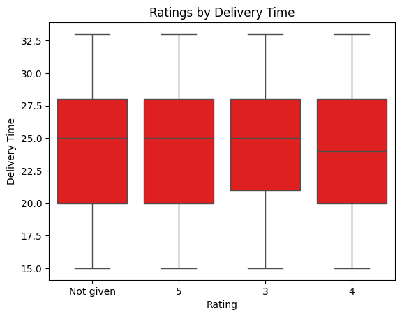

```python
# Plot the Ratings vs the Delivery Time
sns.boxplot(data=df, x='rating', y='delivery_time',color='red');
plt.title('Ratings by Delivery Time');
plt.xlabel('Rating');
plt.ylabel('Delivery Time');
```

Observations: There is no such significant observation between delivery time and rating.

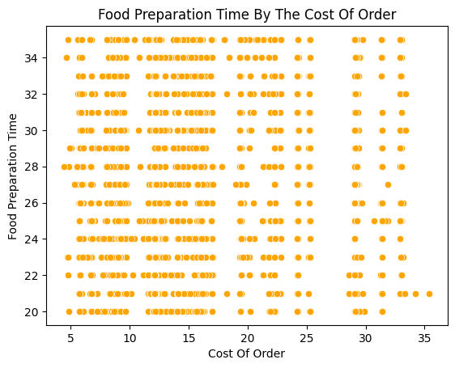

```python
# Plot The Food Preparation Time By The Cost Of Order
sns.scatterplot(data=df, x='cost_of_the_order', y='food_preparation_time', color='orange')
plt.title('Food Preparation Time By The Cost Of Order');
plt.xlabel('Cost Of Order');
plt.ylabel('Food Preparation Time');
```

Observations: They are not linear. Cost of the order does not mean it takes more time to prepare the food.

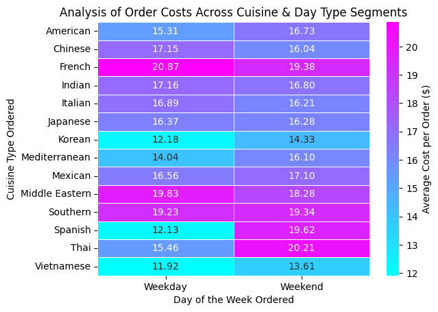

```python
# Find the average cost associated with each different food group by day of the week
data_map = df.groupby(['cuisine_type', 'day_of_the_week'])['cost_of_the_order'].mean()
data_table = data_map.unstack()
sns.heatmap(data_table,annot=True, fmt=".2f", cmap="cool",
            linewidths=.6, cbar_kws={'label': 'Average Cost per Order ($)'})
plt.title('Analysis of Order Costs Across Cuisine & Day Type Segments')
plt.xlabel('Day of the Week Ordered')
plt.ylabel('Cuisine Type Ordered')
plt.show()
```

Observations: 1.Average cost French cuisine is 20.87 on a Weekday and 19.38 on a Weekend. 2.Middle Eastern 19.83 Weekday and Southern 19.23 Weekday also high average prices. 3.Vietnamese has the lowest average cost on both Weekdays 11.92 and Weekends 13.61. 4.Orders are more expensive on the weekends for Thai, Spanish, Vietnamese, Korean, and Mediterranean cuisines as compared to weekdays.

### **Question 13:** The company wants to provide a promotional offer in the advertisement of the restaurants. The condition to get the offer is that the restaurants must have a rating count of more than 50 and the average rating should be greater than 4. Find the restaurants fulfilling the criteria to get the promotional offer. [3 marks]

```python
#filter data with only rated reviews
rated_review= df[df['rating']!='Not given'].copy()

#convert 'rating' datatype from character to numeric
rated_review['rating'] = pd.to_numeric(rated_review['rating'])

#find count and aggregate value of rating
group_data= rated_review.groupby('restaurant_name')['rating'].agg(['count', 'mean'])

#filter the restaurant only with more than 50 ratings and average rating greater than 4
promo_restaurant = group_data[(group_data['count'] > 50) & (group_data['mean'] > 4)]
promo_restaurant
```

| restaurant_name | count | mean |
| --- | --- | --- |
| Blue Ribbon Fried Chicken | 64 | 4.328125 |
| Blue Ribbon Sushi | 73 | 4.219178 |
| Shake Shack | 133 | 4.278195 |
| The Meatball Shop | 84 | 4.511905 |

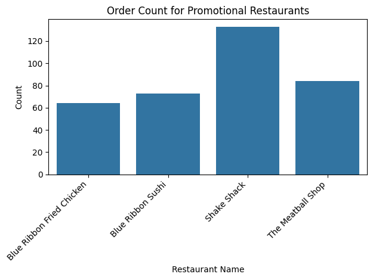

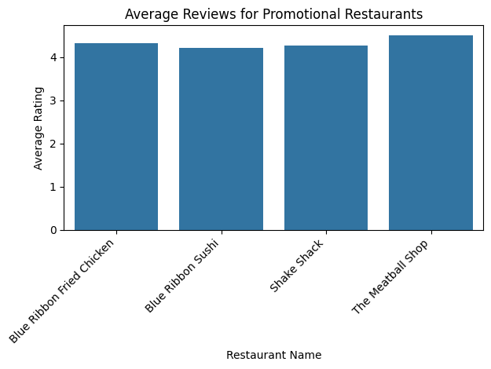

```python
# Visualize the order count for the restaurants those got reviews more than 50
sns.barplot(x=promo_restaurant.index, y='count', data=promo_restaurant)
plt.title('Order Count for Promotional Restaurants')
plt.xlabel('Restaurant Name')
plt.ylabel('Count')
plt.xticks(rotation=45, ha='right')
plt.tight_layout()
plt.show()

# Visualize the average rating for the restaurants those got average reviews more than 4
sns.barplot(x=promo_restaurant.index, y='mean', data=promo_restaurant)
plt.title('Average Reviews for Promotional Restaurants')
plt.xlabel('Restaurant Name')
plt.ylabel('Average Rating')
plt.xticks(rotation=45, ha='right')
plt.tight_layout()
plt.show()
```

#### Observations:

1. There are only 4 restaurants having more than 50 reviews and with average rating more than 4
2. 'Shake Shack' got the highest number of ratings total 133

### **Question 14:** The company charges the restaurant 25% on the orders having cost greater than 20 dollars and 15% on the orders having cost greater than 5 dollars. Find the net revenue generated by the company across all orders. [3 marks]

```python
import numpy as np
#adding a extra field 'net_revenue' based on the conditions to generate the revenues
conditions = [
    df['cost_of_the_order'] > 20,
    df['cost_of_the_order'] > 5
]
choices = [df['cost_of_the_order'] * 0.25, df['cost_of_the_order'] * 0.15]

df['net_revenue'] = np.select(conditions, choices, default=0)
print("Net revenue generated by the company across all orders:", df['net_revenue'].sum())

#categorizing the revenue
percent_25_revenue = df[df['cost_of_the_order'] > 20]['net_revenue'].sum()
print('percent_25_revenue: ', percent_25_revenue)
percent_15_revenue = df[(df['cost_of_the_order'] > 5) & (df['cost_of_the_order'] <=20)]['net_revenue'].sum()
print('percent_15_revenue: ', percent_15_revenue)
```

```
Net revenue generated by the company across all orders: 6166.303
percent_25_revenue:  3688.7275
percent_15_revenue:  2477.5755
```

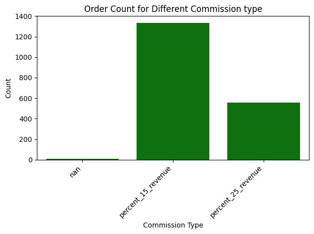

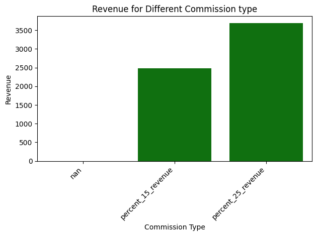

```python
#Adding 'commission_type' field in the dataset
conditions = [
    df['cost_of_the_order'] > 20,
    df['cost_of_the_order'] > 5
]
commission = ['percent_25_revenue','percent_15_revenue']

df['commission_type'] = np.select(conditions, commission, default='nan')

#Grouping data as per commission type to calculate the total revenue and total number of orders in each category
df_data= df.groupby('commission_type')['net_revenue'].agg(['count', 'sum'])

# Visualize the order count for the orders satisfying the conditions
sns.barplot(x=df_data.index, y='count', data=df_data, color ='green')
plt.title('Order Count for Different Commission type')
plt.xlabel('Commission Type')
plt.ylabel('Count')
plt.xticks(rotation=45, ha='right')
plt.tight_layout()
plt.show()

# Visualize total revenue for the different commission type
sns.barplot(x=df_data.index, y='sum', data=df_data, color ='green')
plt.title('Revenue for Different Commission type')
plt.xlabel('Commission Type')
plt.ylabel('Revenue')
plt.xticks(rotation=45, ha='right')
plt.tight_layout()
plt.show()
```

#### Observations:

- Net revenue generated by the company across all orders: 6166.303
- percent_25_revenue: 3688.7275 percent_15_revenue: 2477. More than 1300 orders generate 15% revenue from the order value and around 500+ orders generate 25% revenue from the order value

### **Question 15:** The company wants to analyze the total time required to deliver the food. What percentage of orders take more than 60 minutes to get delivered from the time the order is placed? (The food has to be prepared and then delivered.) [2 marks]

```python
#adding a new field 'total_food_delivery_time' into the dataset
df['total_food_delivery_time'] = df['food_preparation_time'] + df['delivery_time']

#get the count of the orders those take more than 60 mins
orders_over_60_mins = df[df['total_food_delivery_time'] > 60].shape[0]

#get the total order count
total_orders = df.shape[0]

#percentage calculation of orders take more than 60 minutes to get delivered from the time the order is placed
percentage_over_60_mins = (orders_over_60_mins / total_orders) * 100

print(f"Percentage of orders taking more than 60 minutes to be delivered: {percentage_over_60_mins:.2f}%")
```

```
Percentage of orders taking more than 60 minutes to be delivered: 10.54%
```

#### Observations:

10.54% orders take more than 60 minutes to deliver the food from the time of order

### **Question 16:** The company wants to analyze the delivery time of the orders on weekdays and weekends. How does the mean delivery time vary during weekdays and weekends? [2 marks]

```python
#get mean delivery time for weekdays and weekends
mean_delivery_time = df.groupby('day_of_the_week')['delivery_time'].mean()
mean_delivery_time
```

| day_of_the_week | delivery_time |
| --- | --- |
| Weekday | 28.340037 |
| Weekend | 22.470022 |

**dtype:** float64

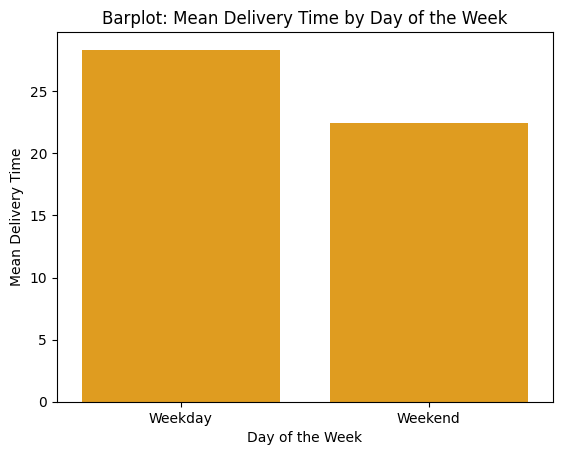

```python
# Visualize the order count for the orders satisfying the conditions
mean_delivery_time_df = mean_delivery_time.reset_index()
sns.barplot(x='day_of_the_week', y='delivery_time', data=mean_delivery_time_df, color ='orange')
plt.title('Barplot: Mean Delivery Time by Day of the Week')
plt.xlabel('Day of the Week')
plt.ylabel('Mean Delivery Time')
plt.show()
```

#### Observations:

Mean delivery time is higher on weekdays, it's 28.34 minutes as compared to 22.47 minutes on weekends. Around 6 minutes higher on weekdays

### Conclusion and Recommendations

- Delivery time is higher on weekdays. Mean delivery time is higher on weekdays, it's 28.34 minutes as compared to 22.47 minutes on weekends
- Total weekend orders are 1300+ and weekdays orders are 500+

Recommendations:

- Number of delivery drivers should be increased on weekdays to reduce the delivery time. It should be inline with the number of orders

### **Question 17:** What are your conclusions from the analysis? What recommendations would you like to share to help improve the business? (You can use cuisine type and feedback ratings to drive your business recommendations.) [6 marks]

### Conclusions:

```python
!jupyter nbconvert --to html "/content/drive/MyDrive/Colab Notebooks/Project_Python_Foundations_FoodHub_Data_Analysis.ipynb"
```

[output not shown]